# Linear_model_with_interactions

Xuening

4/16/2020

## Load data and EDA

```r
url <- "https://raw.githubusercontent.com/genomicsclass/dagdata/master/inst/extdata/spider_wolff_gorb_2013.csv"
filename <- "spider.csv"
if (!file.exists(filename)) download.file(url, filename)
spider <- read.csv(filename, skip=1)
table(spider$leg,spider$type)
```

```
##
##      pull push
##   L1   34   34
##   L2   15   15
##   L3   52   52
##   L4   40   40
```

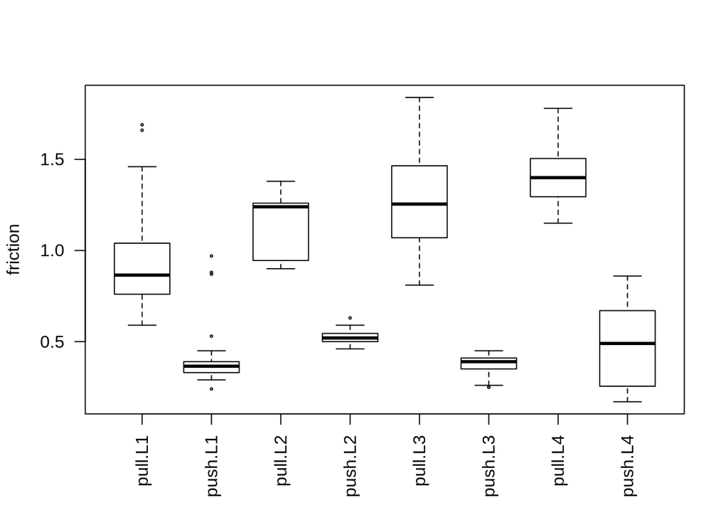

```r
boxplot(spider$friction~spider$type*spider$leg,las=2,cex=0.3,xlab="",ylab="friction") # las=2 give vertical x labels
```

## Fit a linear model

Design a model matrix that records the condition of both push/pull and leg number.

```r
X <- model.matrix(~type+leg,data=spider)
head(X)
```

```
##   (Intercept) typepush legL2 legL3 legL4
## 1           1        0     0     0     0
## 2           1        0     0     0     0
## 3           1        0     0     0     0
## 4           1        0     0     0     0
## 5           1        0     0     0     0
## 6           1        0     0     0     0
```

```r
colSums(X)
```

```
## (Intercept)    typepush       legL2       legL3       legL4
##         282         141          30         104          80
```

The column sum corresponds with the table. Now fit a linear model.

```r
fit <- lm(spider$friction~X+0)
summary(fit)
```

```
##
## Call:
## lm(formula = spider$friction ~ X + 0)
##
## Residuals:
##      Min       1Q   Median       3Q      Max
## -0.46392 -0.13441 -0.00525  0.10547  0.69509
##
## Coefficients:
##              Estimate Std. Error t value Pr(>|t|)
## X(Intercept)  1.05392    0.02816  37.426  < 2e-16 ***
## Xtypepush    -0.77901    0.02482 -31.380  < 2e-16 ***
## XlegL2        0.17192    0.04569   3.763 0.000205 ***
## XlegL3        0.16049    0.03251   4.937 1.37e-06 ***
## XlegL4        0.28134    0.03438   8.183 1.01e-14 ***
## ---
## Signif. codes:  0 '***' 0.001 '**' 0.01 '*' 0.05 '.' 0.1 ' ' 1
##
## Residual standard error: 0.2084 on 277 degrees of freedom
## Multiple R-squared:  0.9515, Adjusted R-squared:  0.9506
## F-statistic:  1087 on 5 and 277 DF,  p-value: < 2.2e-16
```

```r
coefs <- coef(fit)
coefs
```

```
## X(Intercept)    Xtypepush       XlegL2       XlegL3       XlegL4
##    1.0539153   -0.7790071    0.1719216    0.1604921    0.2813382
```

## Interpret some coefficients

The second coefficient is the difference in mean friction between type pull and push.

```r
library(dplyr)
means <- spider %>% group_by(type) %>% summarize(mean=mean(friction))
means
```

```
## # A tibble: 2 x 2
##   type   mean
##   <fct> <dbl>
## 1 pull  1.21
## 2 push  0.432
```

```r
means$mean[2]-means$mean[1]
```

```
## [1] -0.7790071
```

```r
coefs["Xtypepush"]
```

```
##  Xtypepush
## -0.7790071
```

Yet the problem lies in the first coefficient. Theoretically it should be the average friction of leg L1 and type pull because this case is represented $[1,0,0,0,0]$ in model matrix and only first coefficient can fit it.

```r
spider %>% group_by(type,leg) %>% summarize(mean=mean(friction))
```

```
## # A tibble: 8 x 3
## # Groups:   type [2]
##   type  leg    mean
##   <fct> <fct> <dbl>
## 1 pull  L1    0.921
## 2 pull  L2    1.15
## 3 pull  L3    1.27
## 4 pull  L4    1.40
## 5 push  L1    0.407
## 6 push  L2    0.527
## 7 push  L3    0.376
## 8 push  L4    0.491
```

```r
coefs[1]
```

```
## X(Intercept)
##     1.053915
```

Oh? The mean of pull+L1 is 0.9214, not first coefficient 1.05. What happened?

## Linear model with interaction

What happened is that we assumed additive effects of `leg` and `type` thus didn’t take into consideration the interactions between them. To fit a linear model with interaction, we need to redesign the model matrix.

```r
X <- model.matrix(~ type + leg + type:leg, data=spider)
head(X)
```

```
##   (Intercept) typepush legL2 legL3 legL4 typepush:legL2 typepush:legL3
## 1           1        0     0     0     0              0              0
## 2           1        0     0     0     0              0              0
## 3           1        0     0     0     0              0              0
## 4           1        0     0     0     0              0              0
## 5           1        0     0     0     0              0              0
## 6           1        0     0     0     0              0              0
##   typepush:legL4
## 1              0
## 2              0
## 3              0
## 4              0
## 5              0
## 6              0
```

```r
colSums(X)
```

```
##    (Intercept)       typepush          legL2          legL3          legL4
##            282            141             30            104             80
## typepush:legL2 typepush:legL3 typepush:legL4
##             15             52             40
```

`typepush:legL2` is just the product of value of `typepush` and `legL2`. Only 15 rows have value 1 for both `typepush` and `legL2`. Let’s fit and see.

```r
fit <- lm(spider$friction~X+0)
summary(fit)
```

```
##
## Call:
## lm(formula = spider$friction ~ X + 0)
##
## Residuals:
##      Min       1Q   Median       3Q      Max
## -0.46385 -0.10735 -0.01111  0.07848  0.76853
##
## Coefficients:
##                 Estimate Std. Error t value Pr(>|t|)
## X(Intercept)     0.92147    0.03266  28.215  < 2e-16 ***
## Xtypepush       -0.51412    0.04619 -11.131  < 2e-16 ***
## XlegL2           0.22386    0.05903   3.792 0.000184 ***
## XlegL3           0.35238    0.04200   8.390 2.62e-15 ***
## XlegL4           0.47928    0.04442  10.789  < 2e-16 ***
## Xtypepush:legL2 -0.10388    0.08348  -1.244 0.214409
## Xtypepush:legL3 -0.38377    0.05940  -6.461 4.73e-10 ***
## Xtypepush:legL4 -0.39588    0.06282  -6.302 1.17e-09 ***
## ---
## Signif. codes:  0 '***' 0.001 '**' 0.01 '*' 0.05 '.' 0.1 ' ' 1
##
## Residual standard error: 0.1904 on 274 degrees of freedom
## Multiple R-squared:   0.96,  Adjusted R-squared:  0.9588
## F-statistic:   821 on 8 and 274 DF,  p-value: < 2.2e-16
```

## Interpret all coefficients

Now let’s interpret all coefficients.

```r
means_df <- spider %>% group_by(type,leg) %>% summarize(mean=mean(friction))
means_df
```

```
## # A tibble: 8 x 3
## # Groups:   type [2]
##   type  leg    mean
##   <fct> <fct> <dbl>
## 1 pull  L1    0.921
## 2 pull  L2    1.15
## 3 pull  L3    1.27
## 4 pull  L4    1.40
## 5 push  L1    0.407
## 6 push  L2    0.527
## 7 push  L3    0.376
## 8 push  L4    0.491
```

```r
coefs <- coef(fit)
coefs
```

```
##    X(Intercept)       Xtypepush          XlegL2          XlegL3          XlegL4
##       0.9214706      -0.5141176       0.2238627       0.3523756       0.4792794
## Xtypepush:legL2 Xtypepush:legL3 Xtypepush:legL4
##      -0.1038824      -0.3837670      -0.3958824
```

`coefs['X(Intercept)']` is the average of L1 pull. `coefs['Xtypepush']` is the difference between L1 push and L1 pull.

```r
means_df[means_df$leg=="L1" & means_df$type=="push",]$mean-means_df[means_df$leg=="L1" & means_df$type=="pull",]$mean
```

```
## [1] -0.5141176
```

```r
coefs['Xtypepush']
```

```
##  Xtypepush
## -0.5141176
```

The average of L2 pull is `coefs['X(Intercept)']`+`coefs["XlegL2"]`:

```r
coefs['X(Intercept)']+coefs["XlegL2"]
```

```
## X(Intercept)
##     1.145333
```

```r
means_df[means_df$leg=="L2" & means_df$type=="pull",]$mean
```

```
## [1] 1.145333
```

The average of L2 push is `coefs['X(Intercept)']`+`coefs["XlegL2"]`+`coefs["Xtypepush:legL2"]`+ `coefs["Xtypepush"]`.

```r
coefs['X(Intercept)']+coefs["XlegL2"]+coefs["Xtypepush:legL2"]+coefs["Xtypepush"]
```

```
## X(Intercept)
##    0.5273333
```

```r
means_df[means_df$leg=="L2" & means_df$type=="push",]$mean
```

```
## [1] 0.5273333
```

The average of L3 pull is `coefs['X(Intercept)']`+`coefs["XlegL3"]`:

```r
coefs['X(Intercept)']+coefs["XlegL3"]
```

```
## X(Intercept)
##     1.273846
```

```r
means_df[means_df$leg=="L3" & means_df$type=="pull",]$mean
```

```
## [1] 1.273846
```

The average of L3 push is `coefs['X(Intercept)']`+`coefs["XlegL3"]`+`coefs["Xtypepush:legL3"]`+ `coefs["Xtypepush"]`.

```r
coefs['X(Intercept)']+coefs["XlegL3"]+coefs["Xtypepush:legL3"]+coefs["Xtypepush"]
```

```
## X(Intercept)
##    0.3759615
```

```r
means_df[means_df$leg=="L3" & means_df$type=="push",]$mean
```

```
## [1] 0.3759615
```

The average of L4 pull is `coefs['X(Intercept)']`+`coefs["XlegL4"]`:

```r
coefs['X(Intercept)']+coefs["XlegL4"]
```

```
## X(Intercept)
##      1.40075
```

```r
means_df[means_df$leg=="L4" & means_df$type=="pull",]$mean
```

```
## [1] 1.40075
```

The average of L4 push is `coefs['X(Intercept)']`+`coefs["XlegL4"]`+`coefs["Xtypepush:legL4"]`+ `coefs["Xtypepush"]`.

```r
coefs['X(Intercept)']+coefs["XlegL4"]+coefs["Xtypepush:legL4"]+coefs["Xtypepush"]
```

```
## X(Intercept)
##      0.49075
```

```r
means_df[means_df$leg=="L4" & means_df$type=="push",]$mean
```

```
## [1] 0.49075
```